# Kaplan-Meier Plots

```r
library(tidyverse)
library(survival)
library(survminer)
library(ggsurvfit)
```

# Data Cleaning

```r
data = read_csv("Breast Cancer METABRIC.csv") |>
  janitor::clean_names()
```

```r
data =
  data |>
  filter(cancer_type != "Breast Sarcoma") |>
  rename(
     three_gene_classifier_subtype = x3_gene_classifier_subtype)|>
  mutate(
    type_of_breast_surgery =
      factor(type_of_breast_surgery),
    cellularity =
      factor(
        cellularity,
        levels = c("Low", "Medium", "High")),
    chemotherapy =
      factor(
        chemotherapy,
        levels = c("No","Yes")),
    cohort =
      factor(cohort),
    er_status_measured_by_ihc =
      factor(
        er_status_measured_by_ihc,
        levels = c("Negative", "Positve"),
        labels = c("Negative", "Positive")), # Fixing Typo
    er_status =
      factor(
        er_status,
        levels = c("Negative", "Positive")),
    neoplasm_histologic_grade =
      factor(neoplasm_histologic_grade),
    her2_status_measured_by_snp6 =
      factor(
        her2_status_measured_by_snp6,
        levels = c("Loss", "Neutral", "Gain")),
    her2_status =
      factor(
        her2_status,
        levels = c("Negative", "Positive")),
    hormone_therapy =
      factor(
        hormone_therapy,
        levels = c("No", "Yes")),
    inferred_menopausal_state =
      factor(
        inferred_menopausal_state,
        levels = c("Pre", "Post")),
    primary_tumor_laterality =
      factor(primary_tumor_laterality,
      levels = c("Left", "Right")),
    overall_survival_status =
      case_match(
        overall_survival_status,
        "Living" ~ 0,
        "Deceased" ~ 1),
    pr_status =
      factor(
        pr_status,
        levels = c("Negative", "Positive")),
    radio_therapy =
      factor(
        radio_therapy,
        levels = c("No", "Yes")),
    relapse_free_status =
      case_match(
        relapse_free_status,
        "Not Recurred" ~ 0,
        "Recurred" ~ 1),
    sex =
      factor(sex),
    three_gene_classifier_subtype =
      factor(three_gene_classifier_subtype),
    tumor_stage =
      factor(tumor_stage),
    patients_vital_status =
      factor(patients_vital_status))
```

# Overall survival

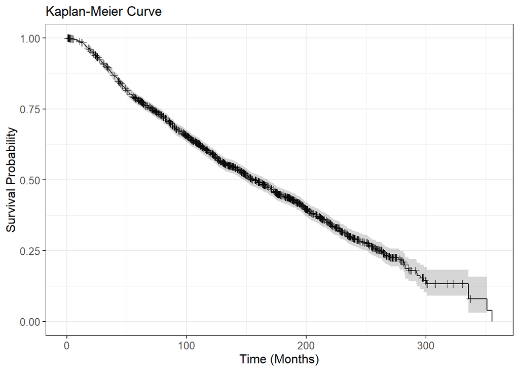

```r
fit = survfit2(Surv(overall_survival_months, overall_survival_status) ~ 1,
              data = data,
              conf.type = "log-log")

ggsurvfit(fit) +
  add_censor_mark() +
  add_confidence_interval() +
  labs(
    title = "Kaplan-Meier Curve",
    x = "Time (Months)")
```

```r
surv_median(fit)
```

```
##   strata   median    lower    upper
## 1    All 156.3333 147.7667 168.2667
```

A Kaplan–Meier curve was fit for overall survival. Confidence intervals were calculated using the log-log method and censoring indicators were added for interpretability. The estimated median survival time was approximately 156 months.

# Univariate Kaplan-Meier Curves

Nearly all categorical variables have been selected for univariate stratification. Variables removed include `patients_vital_status`, `her2_status_measured_by_snp6`, `er_status_measured_by_ihc`, and `sex`.

`patients_vital_status` is not a pre-existing characteristic, but rather an outcome-derived variable.

`her2_status_measured_by_snp6` and `er_status_measured_by_ihc` columns represent specific measurements of ER and HER2 statuses. These are redundant due to the more general columns `her2_status` and `er_status`.

`sex` is excluded since the dataset only consists of female patients.

```r
cat_vars =
  data |>
  select(where(is.factor),
         -c(patients_vital_status,
            her2_status_measured_by_snp6,
            er_status_measured_by_ihc,
            sex)) |>
  names()
```

```r
surv_obj = Surv(time = data$overall_survival_months,
                event = data$overall_survival_status)

km_plot_func = function(fit, var) {

  ggsurvfit(fit) +
    add_pvalue(location = "annotation",
               caption = "Log-rank {p.value}") +
    add_censor_mark() +
    add_confidence_interval() +
    labs(
      title = paste0("KM-Curve Stratified by Variable: ", var),
      x = "Time (Months)")

}

km_results = tibble(
    variable = cat_vars) |>
  mutate(
    formula  = map(variable, \(var) as.formula(paste0("surv_obj ~ ", var))),
    fit      = map(formula, \(f) survfit2(f, data = data, conf.type = "log-log")),
    km_plot  = map2(fit, variable, \(fit, var) km_plot_func(fit, var)),
    log_rank = map_dbl(formula, \(f) survdiff(f, data = data)$pvalue))
```

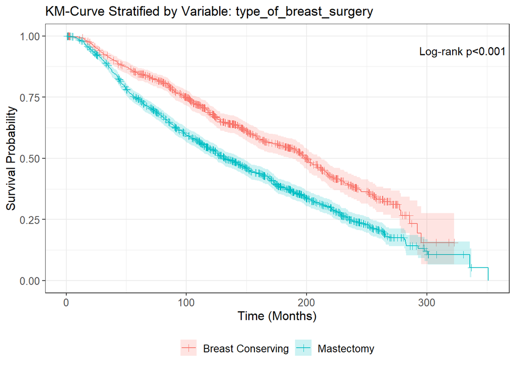

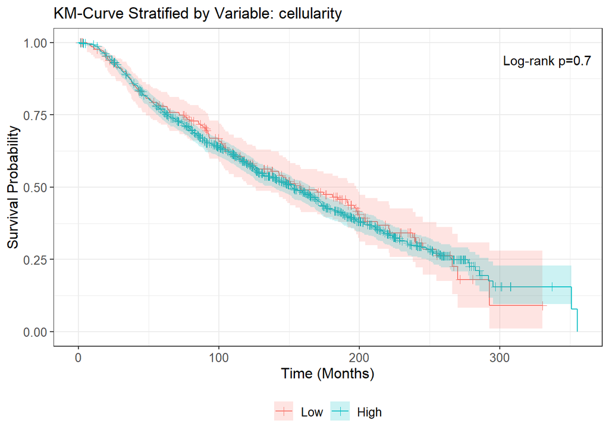

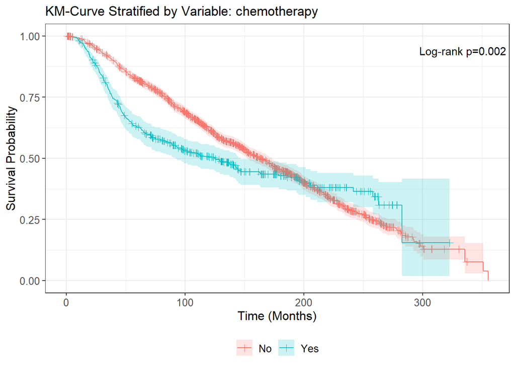

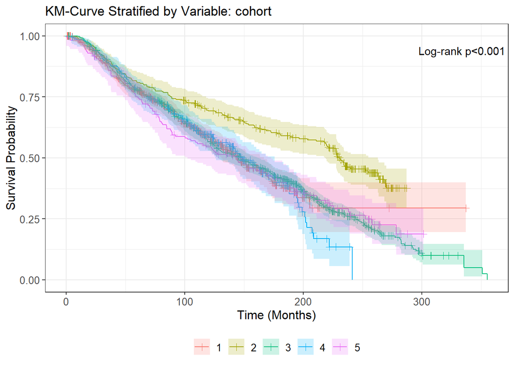

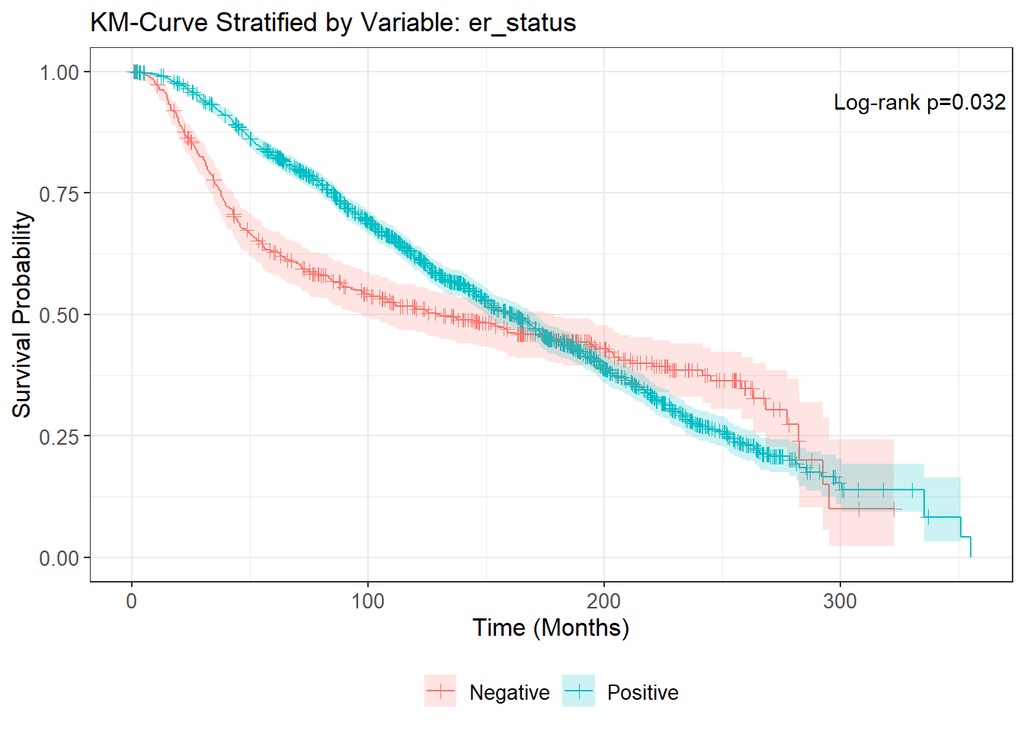

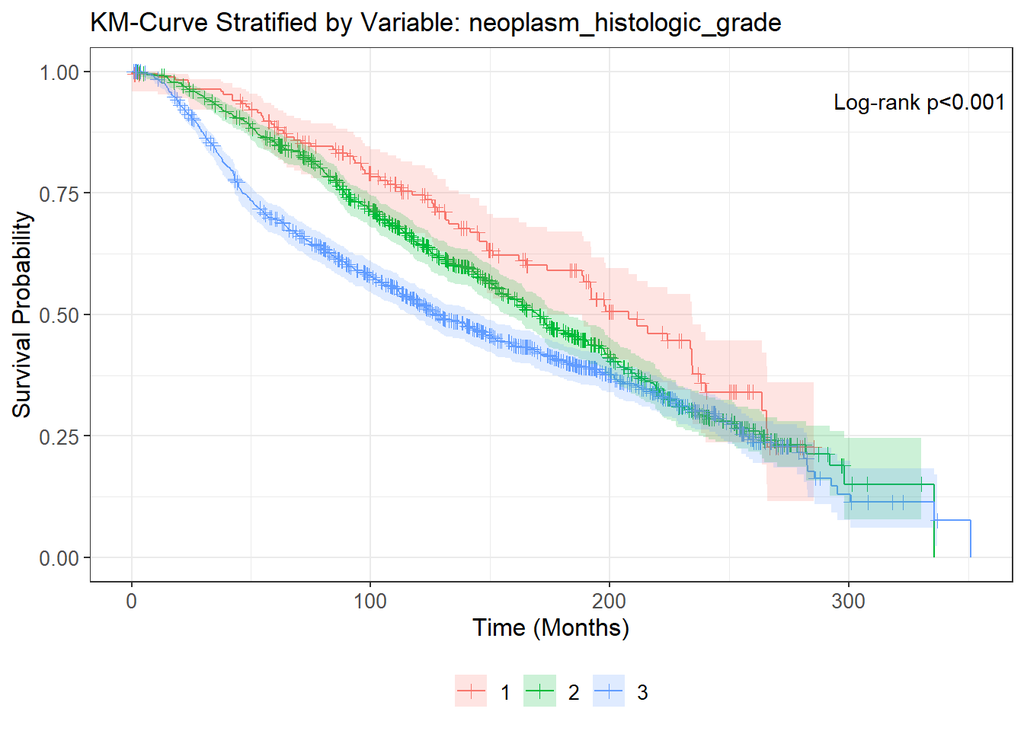

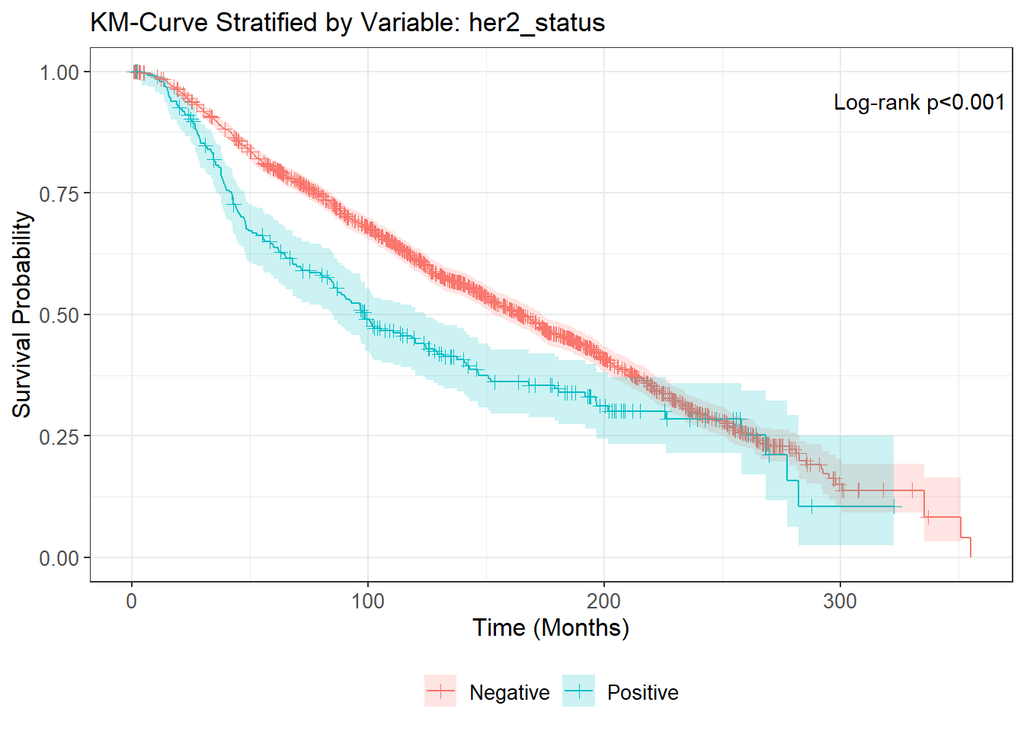

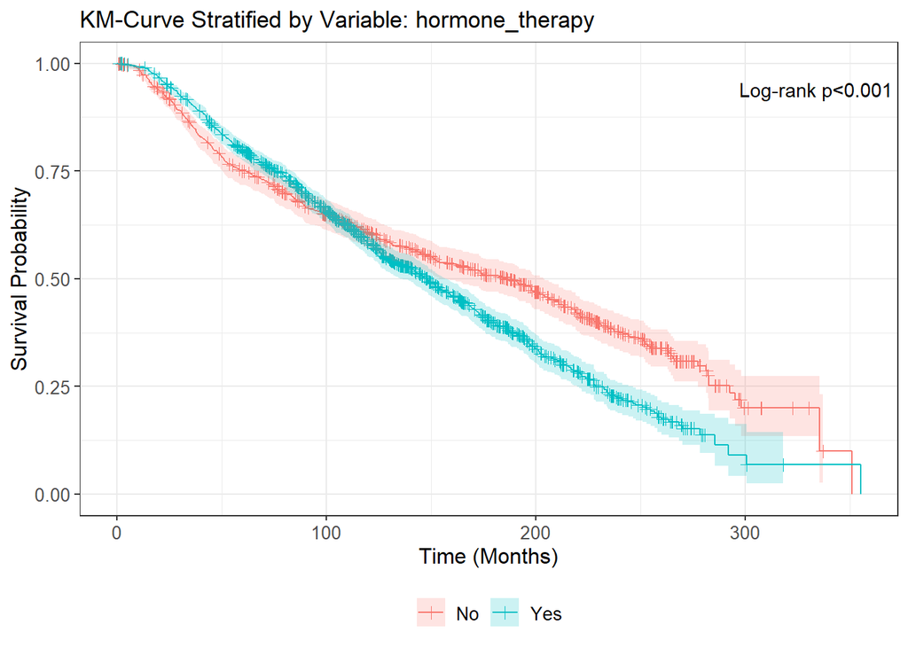

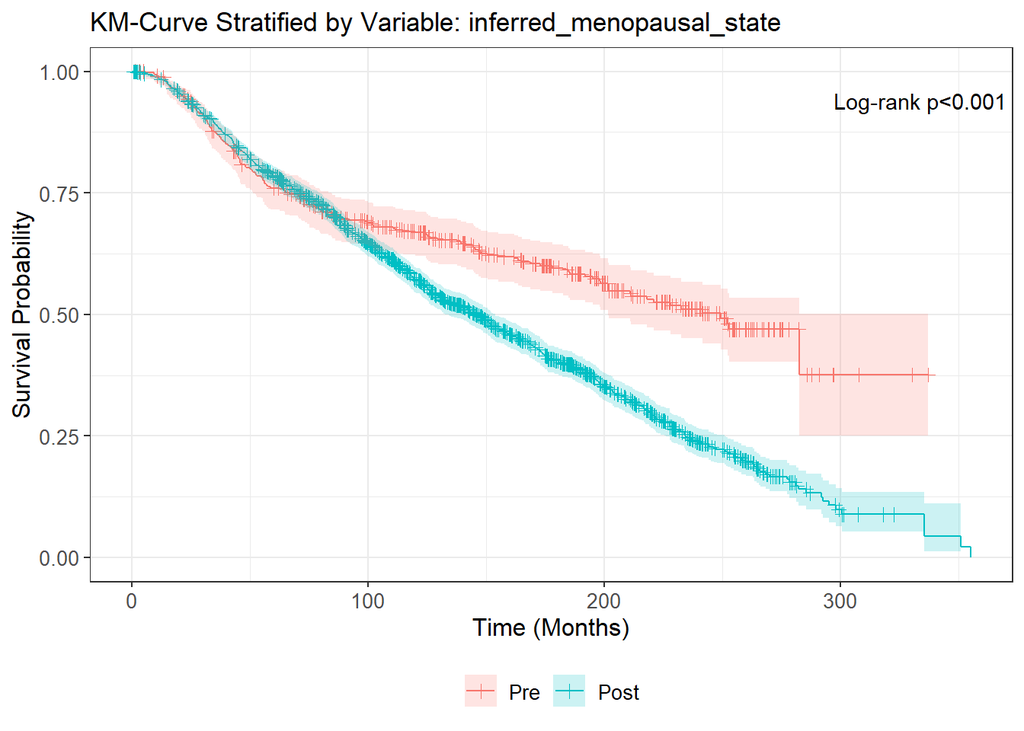

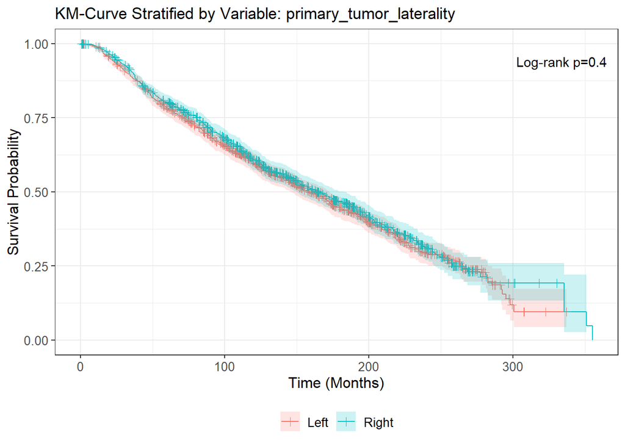

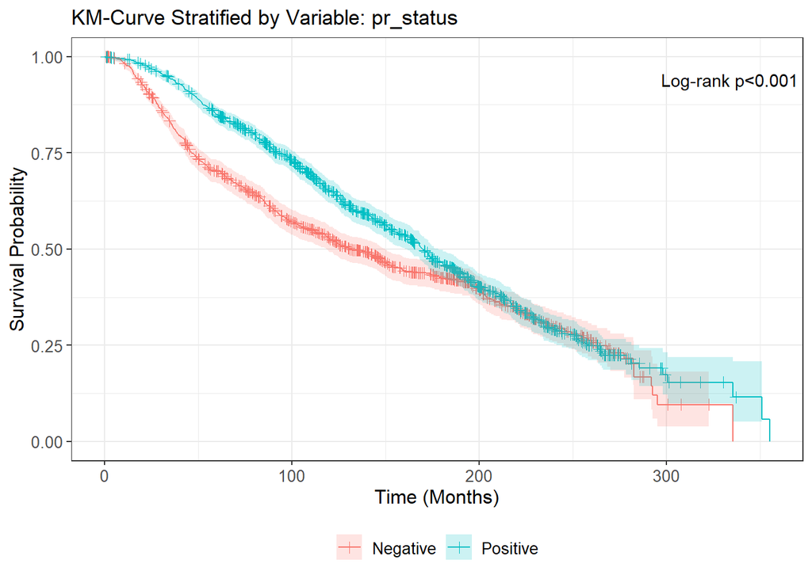

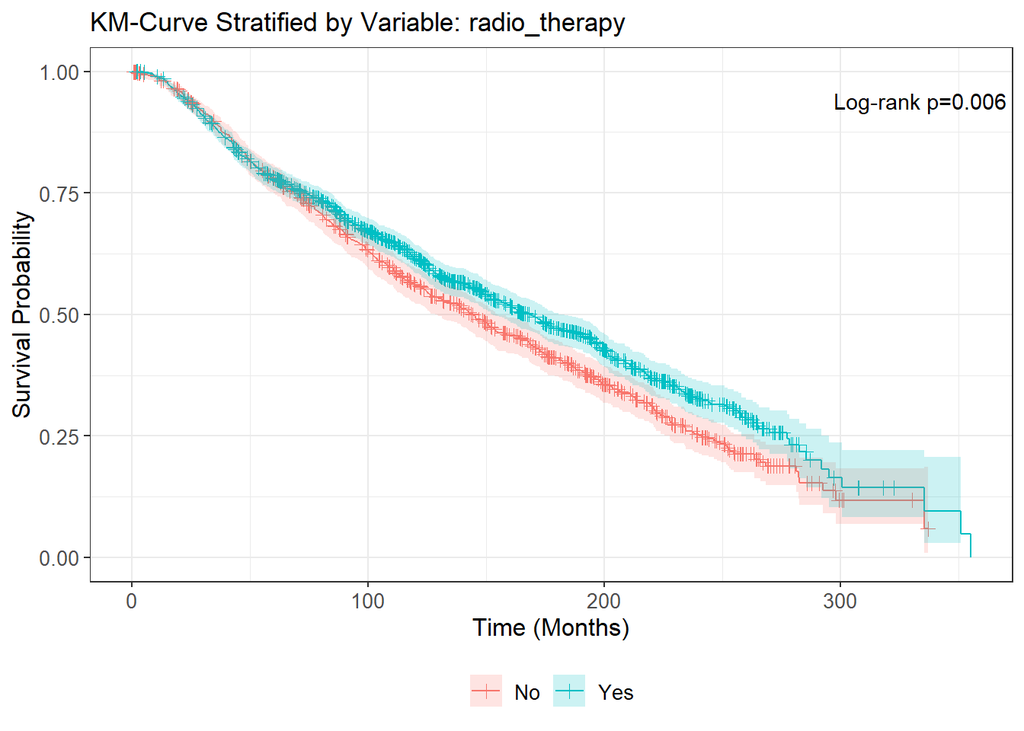

[2 more figures not shown]

```r
km_results |>
  pull(km_plot)
```

# Significant Variables Determined by Log-Rank Test

The log-rank test (and CoxPH models) rely on the proportional hazards assumption. While KM curves are not a formal test of proportional hazards, dramatically crossing curves can indicate poor performance of the log-rank test and difficult interpretation. Therefore, variables whose KM plots contained heavily crossing curves or strong non-parallel patterns were excluded from the list of possibly significant variables.

Excluded variables include:

`chemotherapy`

`er_status`

`hormone_therapy`

`three_gene_classifier_subtype`

```r
sig_vars =
  km_results |>
  filter(log_rank < 0.05,
         !variable %in% c("chemotherapy",
                          "er_status",
                          "hormone_therapy",
                          "three_gene_classifier_subtype")) |>
  arrange(log_rank) |>
  select(variable, log_rank)

sig_vars |> knitr::kable()
```

| variable | log_rank |
| --- | --- |
| tumor_stage | 0.0000000 |
| type_of_breast_surgery | 0.0000000 |
| inferred_menopausal_state | 0.0000000 |
| cohort | 0.0000000 |
| neoplasm_histologic_grade | 0.0000019 |
| her2_status | 0.0000090 |
| pr_status | 0.0000725 |
| radio_therapy | 0.0059118 |

After filtering for a log-rank p-value < 0.05 and excluding variables with strongly non-parallel KM curves, the following variables remained significant. These may represent clinically or biologically relevant predictors of overall survival for breast cancer.